# STAT 516 Lec 10

Randomized complete block split-plot design

Karl Gregory

2026-10-26

# Alfalfa data from Dr. Longnecker’s notes

- Six fields; three plots in each field; four sub-plots in each plot.
- Each plot randomly assigned a type of alfalfa.
- Each sub-plot randomly assigned a cutting date.
- Response for each subplot is yield in tons/acre in the following year.

[figure not shown]

# Alfalfa

```r
alfalfa <- data.frame(yield = c(2.17,1.88,1.62,2.34,1.58,1.66,
                                1.56,1.26,1.22,1.59,1.25,0.94,
                                2.29,1.60,1.67,1.91,1.39,1.12,
                                2.23,2.01,1.82,2.10,1.66,1.10,
                                2.33,2.01,1.70,1.78,1.42,1.35,
                                1.38,1.30,1.85,1.09,1.13,1.06,
                                1.86,1.70,1.81,1.54,1.67,0.88,
                                2.27,1.81,2.01,1.40,1.31,1.06,
                                1.75,1.95,2.13,1.78,1.31,1.30,
                                1.52,1.47,1.80,1.37,1.01,1.31,
                                1.55,1.61,1.82,1.56,1.23,1.13,
                                1.56,1.72,1.99,1.55,1.51,1.33),
                      variety = as.factor(c(rep("ladak",24),
                                            rep("cossack",24),
                                            rep("ranger",24))),
                      date = as.factor(rep(c(rep("none",6),
                                             rep("sep01",6),
                                             rep("sep20",6),
                                             rep("oct07",6)),
                                           3)),
                      field = as.factor(rep(1:6,12)))
```

# Alfalfa

```r
head(alfalfa,n = 26)
```

```
   yield variety  date field
1   2.17   ladak  none     1
2   1.88   ladak  none     2
3   1.62   ladak  none     3
4   2.34   ladak  none     4
5   1.58   ladak  none     5
6   1.66   ladak  none     6
7   1.56   ladak sep01     1
8   1.26   ladak sep01     2
9   1.22   ladak sep01     3
10  1.59   ladak sep01     4
11  1.25   ladak sep01     5
12  0.94   ladak sep01     6
13  2.29   ladak sep20     1
14  1.60   ladak sep20     2
15  1.67   ladak sep20     3
16  1.91   ladak sep20     4
17  1.39   ladak sep20     5
18  1.12   ladak sep20     6
19  2.23   ladak oct07     1
20  2.01   ladak oct07     2
21  1.82   ladak oct07     3
22  2.10   ladak oct07     4
23  1.66   ladak oct07     5
24  1.10   ladak oct07     6
25  2.33 cossack  none     1
26  2.01 cossack  none     2
```

# Randomized complete block split plot design

- Each EU randomly assigned to one level of whole-plot factor.
- Each EU receives all levels of split-plot factor in random order.
- Groups of EUs over which this is replicated are treated as blocks.

# Treatment effects model for RCB split-plot design

Assume
$$Y_{ijk} = \mu + \tau_i + \gamma_j + (\tau\gamma)_{ij} + C_k + (\tau C)_{ik} + \varepsilon_{ijk},$$
for $i = 1,\dots,a$, $j = 1,\dots,b$ and $k= 1,\dots,c$, where

- $Y_{ijk}$ is the response of sub-plot $j$ from whole plot $i$ in block $k$.
- the $\tau_i$ are treatment effects for the whole-plot factor.
- the $\gamma_j$ are treatment effects for the split-plot factor.
- the $(\tau \gamma)_{ij}$ are interaction effects between the factors.
- the $C_k$ are independent $\text{Normal}(0,\sigma_C^2)$ block effects.
- the $(\tau C)_{ik}$ are indep $\text{Normal}(0,\sigma_{AC}^2)$ whole-plot$\times$block effects.
- the $\varepsilon_{ijk}$ are independent $\text{Normal}(0,\sigma_{\varepsilon}^2)$ error terms.

Define the cell means as
$$\mu_{ij} = \mu + \tau_i + \gamma_j + (\tau\gamma)_{ij}, \quad i = 1,\dots,a, \quad j = 1,\dots,b.$$

# Goals in the RCB split-plot design

In the RCB split-plot model we will focus on how to:

1. Decompose the variability in the $Y_{ijk}$ into its sources.
2. Test for significance of main effects and interaction.
3. Estimate the variance components $\sigma_C^2$, $\sigma_{AC}^2$, and $\sigma_\varepsilon^2$.
4. Make comparisons between treatment means.
5. Check whether the model assumptions are satisfied.

# Sums of squares for the RCB split-plot design

[output not shown]

# Expected mean squares in RCB split plot design

| Source | Df | Expected mean square |
| --- | --- | --- |
| A | $a-1$ | $bc \theta_A^2 + b\sigma_{AC}^2 + \sigma_\varepsilon^2$ |
| C | $c-1$ | $ab\sigma_C^2 + b\sigma_{AC}^2 + \sigma_\varepsilon^2$ |
| AC | $(a-1)(c-1)$ | $b\sigma_{AC}^2 + \sigma_\varepsilon^2$ |
| B | $b-1$ | $ac \theta_B^2 + \sigma_\varepsilon^2$ |
| AB | $(a-1)(b-1)$ | $c \theta_{AB}^2 + \sigma_\varepsilon^2$ |
| Error | $a(b-1)(c-1)$ | $\sigma_\varepsilon^2$ |

In the above

- $\theta_A^2 = (a-1)^{-1}\sum_{i=1}^a(\bar \mu_{i.} - \bar \mu_{..})^2$
- $\theta_B^2 = (b-1)^{-1}\sum_{j=1}^b(\bar \mu_{.j} - \bar \mu_{..})^2$
- $\theta_{AB}^2 = [(a-1)(b-1)]^{-1}\sum_{i=1}^a\sum_{j=1}^b(\mu_{ij} - (\bar \mu_{i.} + \bar \mu_{.j} - \bar \mu_{..}))^2$

# ANOVA table for RCB split-plot design

| Source | Df | SS | MS | F value |
| --- | --- | --- | --- | --- |
| A | $a-1$ | $\operatorname{SS}_{\operatorname{A}}$ | $\operatorname{MS}_{\operatorname{A}}$ | $F_{\operatorname{A}}= \operatorname{MS}_{\operatorname{A}}/ \textcolor{red}{\operatorname{MS}_{\operatorname{AC}}}$ |
| C | $c-1$ | $\operatorname{SS}_{\operatorname{C}}$ | $\operatorname{MS}_{\operatorname{C}}$ | $F_{\operatorname{C}}= \operatorname{MS}_{\operatorname{C}}/ \textcolor{red}{\operatorname{MS}_{\operatorname{AC}}}$ |
| AC | $(a-1)(c-1)$ | $\operatorname{SS}_{\operatorname{AC}}$ | $\operatorname{MS}_{\operatorname{AC}}$ | $F_{\operatorname{AC}}= \operatorname{MS}_{\operatorname{AC}}/ \operatorname{MS}_{\operatorname{Error}}$ |
| B | $b-1$ | $\operatorname{SS}_{\operatorname{B}}$ | $\operatorname{MS}_{\operatorname{B}}$ | $F_{\operatorname{B}}= \operatorname{MS}_{\operatorname{B}}/ \operatorname{MS}_{\operatorname{Error}}$ |
| AB | $(a-1)(b-1)$ | $\operatorname{SS}_{\operatorname{AB}}$ | $\operatorname{MS}_{\operatorname{AB}}$ | $F_{\operatorname{AB}}= \operatorname{MS}_{\operatorname{AB}}/ \operatorname{MS}_{\operatorname{Error}}$ |
| Error | $a(b-1)(c-1)$ | $\operatorname{SS}_{\operatorname{Error}}$ | $\operatorname{MS}_{\operatorname{Error}}$ |  |
| Total | $abc-1$ | $\operatorname{SS}_{\operatorname{Tot}}$ |  |  |

1. Reject $H_0$: $\bar \mu_{1.} = \dots = \bar\mu_{a.}$ if $F_{\operatorname{A}}> F_{a-1,\textcolor{red}{(a-1)(c-1)},\alpha}$.
2. Reject $H_0$: $\sigma_C^2 = 0$ if $F_{\operatorname{C}}> F_{c-1,\textcolor{red}{(a-1)(c-1)},\alpha}$.
3. Reject $H_0$: $\sigma_{AC}^2 = 0$ if $F_{\operatorname{AC}}> F_{(a-1)(c-1),a(b-1)(c-1),\alpha}$.
4. Reject $H_0$: $\bar \mu_{.1} = \dots = \bar \mu_{.b}$ if $F_{\operatorname{B}}> F_{b-1,a(b-1)(c-1),\alpha}$.
5. Reject $H_0$: $\mu_{ij} = \bar \mu_{i.} + \bar \mu_{.j} - \bar \mu_{..} ~ \forall ij$ if $F_{\operatorname{AB}}> F_{(a-1)(b-1),a(b-1)(c-1),\alpha}$.

# Alfalfa

`anova()` on `lm()` output gives wrong p-vals for `variety` and `field`.

```r
lm_out <- lm(yield ~ variety + date + variety:date + field + field:variety,
             data = alfalfa)
anova(lm_out)
```

```
Analysis of Variance Table

Response: yield
              Df Sum Sq Mean Sq F value  Pr(>F)
variety        2   0.18   0.088    3.12  0.0538 .
date           3   1.97   0.658   23.41 2.8e-09 ***
field          5   4.14   0.828   29.47 3.8e-13 ***
variety:date   6   0.21   0.036    1.27  0.2883
variety:field 10   1.36   0.136    4.83  0.0001 ***
Residuals     45   1.26   0.028
---
Signif. codes:  0 '***' 0.001 '**' 0.01 '*' 0.05 '.' 0.1 ' ' 1
```

# Alfalfa

```r
y <- alfalfa$yield
y... <- predict(lm(yield ~ 1,data = alfalfa))
yi.. <- predict(lm(yield ~ variety,data = alfalfa))
y.j. <- predict(lm(yield ~ date,data = alfalfa))
y..k <- predict(lm(yield ~ field,data = alfalfa))
yij. <- predict(lm(yield ~ variety + date + variety:date,data = alfalfa))
yi.k <- predict(lm(yield ~ variety + field + variety:field,data = alfalfa))

SST <- sum((y - y...)^2)
SSA <- sum((yi.. - y...)^2)
SSC <- sum((y..k - y...)^2)
SSAC <- sum((yi.k - (yi.. + y..k - y...))^2)
SSB <- sum((y.j. - y...)^2)
SSAB <- sum((yij. - (yi.. + y.j. - y...))^2)
SSE <- SST - (SSA + SSC + SSAC + SSB + SSAB)
```

# Alfalfa

```r
a <- 3
b <- 4
c <- 6

MSA <- SSA / (a-1)
MSC <- SSC / (c-1)
MSAC <- SSAC / ((c-1)*(a-1))
MSB <- SSB / (b-1)
MSAB <- SSAB / ((a-1)*(b-1))
MSE <- SSE / (a*(b-1)*(c-1))

FA_incorrect <- MSA / MSE
FC_incorrect <- MSC / MSE
FA <- MSA / MSAC
FC <- MSC / MSAC
FAC <- MSAC / MSE
FB <- MSB / MSE
FAB <- MSAB / MSE

pA_incorrect <- 1 - pf(FA_incorrect,a-1,a*(b-1)*(c-1))
pC_incorrect <- 1 - pf(FC_incorrect,c-1,a*(b-1)*(c-1))
pA <- 1 - pf(FA,a-1,(c-1)*(a-1))
pC <- 1 - pf(FC,c-1,(c-1)*(a-1))
pAC  <- 1 - pf(FAC,(c-1)*(a-1),a*(b-1)*(c-1))
pB <- 1 - pf(FB,b-1,a*(b-1)*(c-1))
pAB <- 1 - pf(FAB,(a-1)*(b-1),a*(b-1)*(c-1))
```

# Alfalfa

Correct ANOVA table:

| Source | Df | SS | MS | F value | p value |
| --- | --- | --- | --- | --- | --- |
| A | 2 | 0.175 | 0.088 | 0.646 | 0.5449 |
| C | 5 | 4.139 | 0.828 | 6.098 | 0.0076 |
| AC | 10 | 1.357 | 0.136 | 4.833 | 0.0001 |
| B | 3 | 1.973 | 0.658 | 23.412 | 0.0000 |
| AB | 6 | 0.215 | 0.036 | 1.274 | 0.2883 |
| Error | 45 | 1.264 | 0.028 |  |  |
| Total | 71 | 9.123 |  |  |  |

# Alfalfa

Correct p values for fixed effects with `lmerTest` package:

```r
library(lmerTest) # first time run install.packages("lmerTest")
lmer_out <- lmer(yield ~ variety + date + variety:date + (1|field) + (1|field:variety),
                 data = alfalfa)
anova(lmer_out)
```

```
Type III Analysis of Variance Table with Satterthwaite's method
             Sum Sq Mean Sq NumDF DenDF F value  Pr(>F)
variety       0.036   0.018     2    10    0.65    0.54
date          1.973   0.658     3    45   23.41 2.8e-09 ***
variety:date  0.215   0.036     6    45    1.27    0.29
---
Signif. codes:  0 '***' 0.001 '**' 0.01 '*' 0.05 '.' 0.1 ' ' 1
```

Rescales $\operatorname{SS}_{\operatorname{A}}$ and $\operatorname{MS}_{\operatorname{A}}$ by the factor $\operatorname{MS}_{\operatorname{Error}}/ \operatorname{MS}_{\operatorname{AC}}$.

# Alfalfa

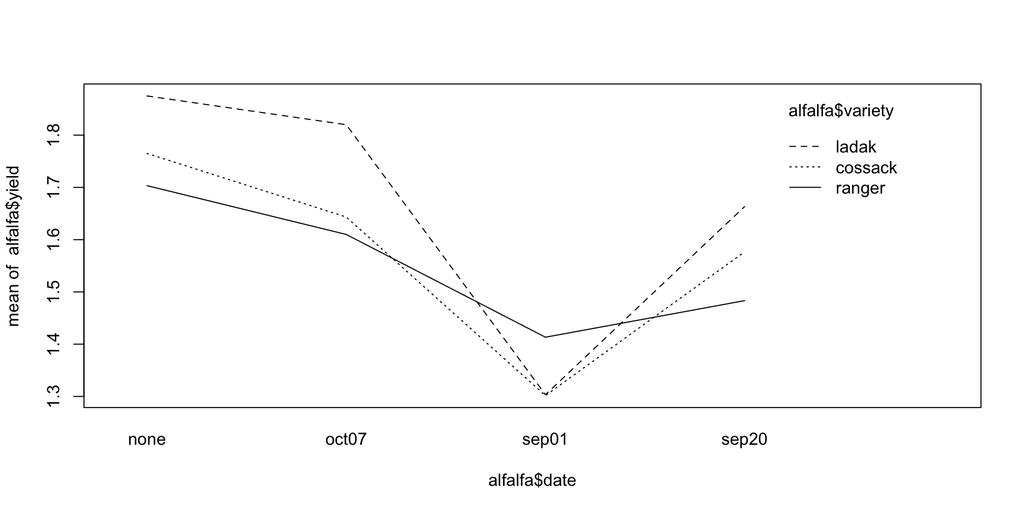

```r
interaction.plot(alfalfa$date,alfalfa$variety,alfalfa$yield)
```

# MoM for variance components in RCB split-plot design

The method of moments estimators for $\sigma_C^2$, $\sigma_{AC}^2$, and $\sigma_{\varepsilon}^2$ are

- $\displaystyle \dot \sigma_{\varepsilon}^2 = \operatorname{MS}_{\operatorname{Error}}$
- $\displaystyle \dot \sigma_{AC}^2 = \frac{\operatorname{MS}_{\operatorname{AC}}- \operatorname{MS}_{\operatorname{Error}}}{b}$
- $\displaystyle \dot \sigma_{C}^2 = \frac{\operatorname{MS}_{\operatorname{C}}- \operatorname{MS}_{\operatorname{AC}}}{ab}$

It is possible to obtain negative values for $\dot \sigma_{AC}^2$ and $\dot \sigma_{C}^2$. Use REML.

# Alfalfa

Obtain REML estimates of $\sigma_C^2$, $\sigma_{AC}^2$, and $\sigma_\varepsilon^2$ from `lmer()`.

```r
summary(lmer_out)$varcor
```

```
 Groups        Name        Std.Dev.
 field:variety (Intercept) 0.164
 field         (Intercept) 0.240
 Residual                  0.168
```

# Variances of some means and difference in means

[output not shown]

# Some (unadjusted) CIs in RCB split plot design

| Target | $(1-\alpha)100\%$ confidence interval |
| --- | --- |
| $\bar \mu_{i.} - \bar \mu_{i'.}$ | $\bar Y_{i..} - \bar Y_{i'..} \pm t_{(a-1)(c-1),\alpha/2}\sqrt{\operatorname{MS}_{\operatorname{AC}}}\sqrt{\frac{2}{bc}}$ |
| $\bar \mu_{.j} - \bar \mu_{.j'}$ | $\bar Y_{.j.} - \bar Y_{.j'.} \pm t_{a(b-1)(c-1),\alpha/2}\sqrt{\operatorname{MS}_{\operatorname{Error}}}\sqrt{\frac{2}{ac}}$ |
| $\mu_{ij} - \mu_{i'j}$ | $\bar Y_{ij.} - \bar Y_{i'j.} \pm t_{\nu^*,\alpha/2}\sqrt{\operatorname{MS}_{\operatorname{AC}}+ (b-1)\operatorname{MS}_{\operatorname{Error}}}\sqrt{\frac{2}{c}}$ |
| $\mu_{ij} - \mu_{ij'}$ | $\bar Y_{ij.} - \bar Y_{ij'.} \pm t_{a(b-1)(c-1),\alpha/2}\sqrt{\operatorname{MS}_{\operatorname{Error}}}\sqrt{\frac{2}{c}}$ |
| $\mu_{ij} - \mu_{i'j'}$ | $\bar Y_{ij.} - \bar Y_{i'j'.} \pm t_{\nu^*,\alpha/2}\sqrt{\operatorname{MS}_{\operatorname{AC}}+ (b-1)\operatorname{MS}_{\operatorname{Error}}}\sqrt{\frac{2}{c}}$ |

In the above $\displaystyle \nu^* = \frac{\operatorname{MS}_{\operatorname{AC}}+ (b-1)\operatorname{MS}_{\operatorname{Error}}}{\frac{\operatorname{MS}_{\operatorname{AC}}^2}{(a-1)(c-1)} + \frac{(b-1)^2\operatorname{MS}_{\operatorname{Error}}^2}{a(b-1)(c-1)}}$ à la Satterthwaite.

# Alfalfa

Dunnett’s comparison of marginal date means with *no cutting* as baseline:
$$\bar Y_{.j.} - \bar Y_{.1.} \pm d_{b-1,a(b-1)(c-1),\alpha}\sqrt{\operatorname{MS}_{\operatorname{Error}}}\sqrt{\frac{2}{ac}}$$
Replace, in previous slide, $t_{a(b-1)(c-1),\alpha/2}$ with $d_{b-1,a(b-1)(c-1),\alpha}$.

# Dunnett’s table

[figure not shown]

Table A.5 from Mohr, Wilson, and Freund (2021)

# Alfalfa

```r
y.1.bar <- mean(alfalfa$yield[alfalfa$date=="none"])
y.2.bar <- mean(alfalfa$yield[alfalfa$date=="sep01"])
y.3.bar <- mean(alfalfa$yield[alfalfa$date=="sep20"])
y.4.bar <- mean(alfalfa$yield[alfalfa$date=="oct07"])


se <- sqrt(MSE) * sqrt(2/(a*c))
me <- 2.44 * se

dtab <- rbind(c(y.2.bar - y.1.bar - me,y.2.bar - y.1.bar + me),
              c(y.3.bar - y.1.bar - me,y.3.bar - y.1.bar + me),
              c(y.4.bar - y.1.bar - me,y.4.bar - y.1.bar + me))

colnames(dtab) <- c("lower","upper")
rownames(dtab) <- c("sep01 - none",
                    "sep20 - none",
                    "oct07 - none")
round(dtab,3)
```

```
              lower  upper
sep01 - none -0.578 -0.305
sep20 - none -0.343 -0.070
oct07 - none -0.226  0.046
```

# Alfalfa

Unadjusted CIs with `ls_means()` from R package `lmerTest`:

```r
ls_means(lmer_out,which="date")
```

```
Least Squares Means table:

          Estimate Std. Error  df t value lower upper Pr(>|t|)
datenone     1.781      0.113 6.1    15.8 1.506 2.056  3.7e-06 ***
dateoct07    1.691      0.113 6.1    15.0 1.416 1.966  5.0e-06 ***
datesep01    1.339      0.113 6.1    11.9 1.065 1.614  2.0e-05 ***
datesep20    1.574      0.113 6.1    14.0 1.300 1.849  7.6e-06 ***
---
Signif. codes:  0 '***' 0.001 '**' 0.01 '*' 0.05 '.' 0.1 ' ' 1

  Confidence level: 95%
  Degrees of freedom method: Satterthwaite
```

# Alfalfa

```r
ls_means(lmer_out, pairwise = TRUE, which = "date")
```

```
Least Squares Means table:

                      Estimate Std. Error df t value    lower    upper Pr(>|t|)
datenone - dateoct07   0.09000    0.05586 45    1.61 -0.02252  0.20252  0.11416
datenone - datesep01   0.44167    0.05586 45    7.91  0.32915  0.55418  4.7e-10
datenone - datesep20   0.20667    0.05586 45    3.70  0.09415  0.31918  0.00059
dateoct07 - datesep01  0.35167    0.05586 45    6.30  0.23915  0.46418  1.1e-07
dateoct07 - datesep20  0.11667    0.05586 45    2.09  0.00415  0.22918  0.04245
datesep01 - datesep20 -0.23500    0.05586 45   -4.21 -0.34752 -0.12248  0.00012

datenone - dateoct07
datenone - datesep01  ***
datenone - datesep20  ***
dateoct07 - datesep01 ***
dateoct07 - datesep20 *
datesep01 - datesep20 ***
---
Signif. codes:  0 '***' 0.001 '**' 0.01 '*' 0.05 '.' 0.1 ' ' 1

  Confidence level: 95%
  Degrees of freedom method: Satterthwaite
```

# References

Mohr, Donna L, William J Wilson, and Rudolf J Freund. 2021. *Statistical Methods*. Academic Press.